# Simple Linear Regression Homework

Stuart McColl

05/01/2021

# Part 1

### Load the data into a dataframe project

```r
library(tidyverse)
library(modelr)
library(broom)
library(ggfortify)
library(infer)

project <- read_csv("data/project_management.csv")
```

# Part 2

### Plot the data, taking estimated_length as the independent variable and actual_length as the dependent variable.

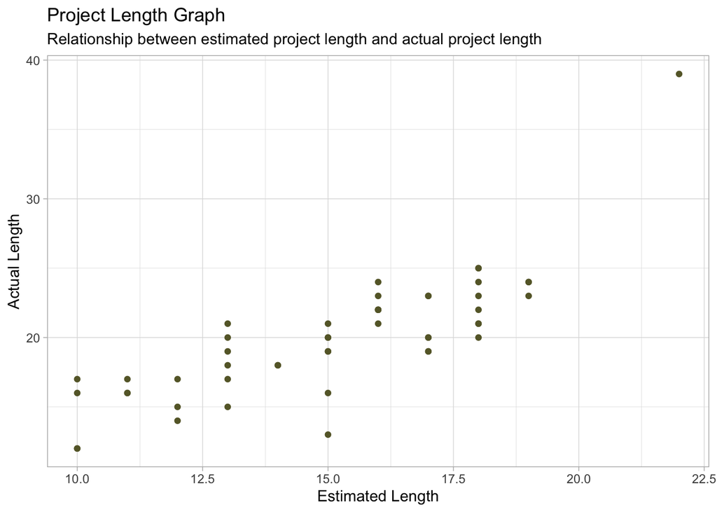

```r
project %>%
  ggplot(aes(x = estimated_length, y = actual_length)) +
  geom_point(col = "#666633") +
  theme_light() +
    labs(title = "Project Length Graph", subtitle = "Relationship between estimated project length and actual project length",
       x = "Estimated Length", y = "Actual Length")
```

# Part 3

### Calculate the correlation coefficient of estimated_length and actual_length and interpret the value you obtain.

```r
project %>%
  summarise(cor = cor(estimated_length, actual_length))
```

| cor |
| --- |
| 0.8046597 |

#### A correlation coefficient of 0.80 is a very strong, positive correlation, which means that as the estimated length increases along the x-axis, the actual length also increases.

# Part 4

### Perform a simple linear regression using actual_length as the dependent variable, and estimated_length as the independent variable. Save the model object to a variable.

```r
model <- lm(formula = actual_length ~ estimated_length, data = project)
model
```

```
##
## Call:
## lm(formula = actual_length ~ estimated_length, data = project)
##
## Coefficients:
##      (Intercept)  estimated_length
##            1.416             1.223
```

# Part 5

### Interpret the regression coefficient of estimated_length (i.e. slope, gradient) you obtain from the model. How do you interpret the r2 value reported by the model?

#### Answer - fitted actual_length = 1.416 + 1.223 * estimated_length

#### 1x increase in estimated_length, changes the actual_length by 1.223.

# Part 6

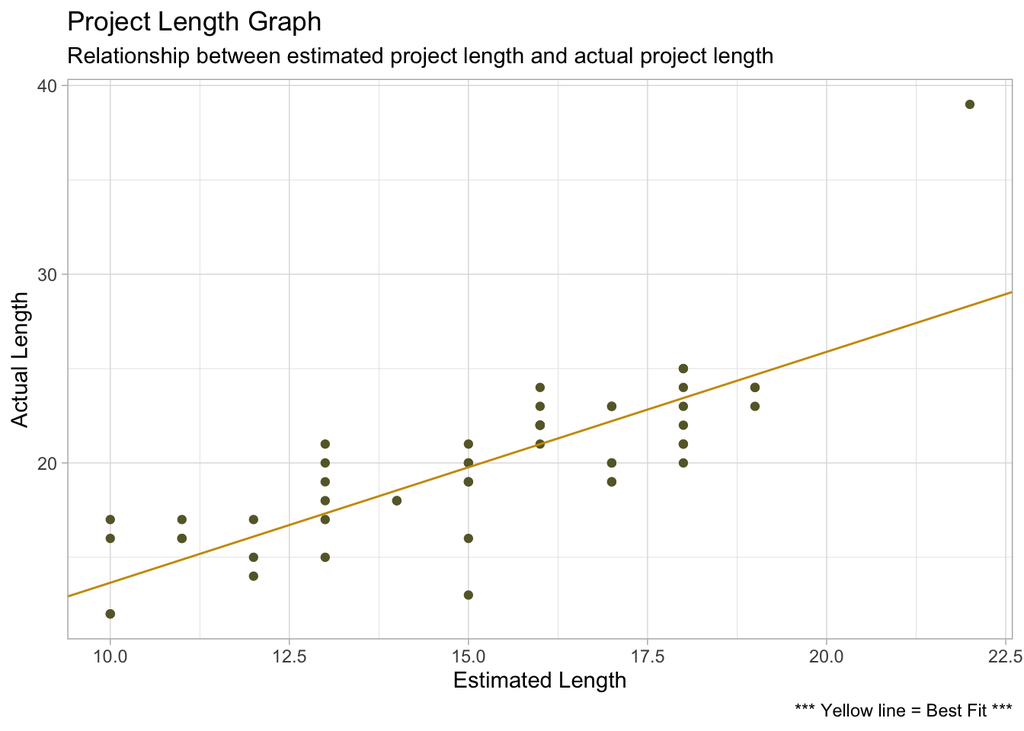

```r
project %>%
  ggplot(aes(x = estimated_length, y = actual_length)) +
  geom_point(col = "#666633") +
  geom_abline(
    intercept = model$coefficients[1],
    slope = model$coefficients[2],
    col = "#cc9900"
  ) +
  theme_light() +
  labs(title = "Project Length Graph", subtitle = "Relationship between estimated project length and actual project length",
       x = "Estimated Length", y = "Actual Length", caption = "*** Yellow line = Best Fit ***")
```

```r
glance <- glance(model)

glance$p.value
```

```
##        value
## 1.911284e-12
```

#### Answer - As the p-value is less than a significance level of both 0.01 and 0.05 (typical), the coefficient is significantly different from zero.